# Machine Learning of Enron Corpus

```python
from IPython.display import HTML

HTML('''<script>
code_show=true;
function code_toggle() {
 if (code_show){
 $('div.input').hide();
 } else {
 $('div.input').show();
 }
 code_show = !code_show
}
$( document ).ready(code_toggle);
</script>
<form action="javascript:code_toggle()"><input type="submit" value="Click here to toggle on/off the raw code."></form>''')
```

See GitHub repository at: https://github.com/tigreryder/EnronMachineLearning

The Enron scandal (https://en.wikipedia.org/wiki/Enron_scandal) was one of the more memorable financial scandals in recent American history. In the course of the government investigation of Enron, a large body of emails was made public. This corpus is a treasure trove of actual emails written between corporate executives, offering up the raw data to help hone machine learning techniques.

Approximately 150 people have their emails catalogued in this collection, but naturally, they were not all involved in committing fraud. In the course of the investigation, there were those who were indicted by the government, those who settled with the government without admitting guilt, and those who testified on behalf of the government in exchange for immunity. We will consider a person who fits into one of these three categories to be a “person of interest”. A USA Today article from 2005 handily helped to identify these persons of interest: http://usatoday30.usatoday.com/money/industries/energy/2005-12-28-enron-participants_x.htm

```python
import sys
import pickle
sys.path.append("../tools/")

import numpy as np
import pandas as pd
import matplotlib as plt
import seaborn as sns

from feature_format import featureFormat, targetFeatureSplit
from tester import dump_classifier_and_data
from tester import test_classifier

from sklearn.cross_validation import train_test_split
from sklearn.ensemble import RandomForestClassifier
from sklearn.metrics import recall_score
from sklearn.metrics import precision_score
from sklearn.metrics import confusion_matrix
from sklearn.cross_validation import StratifiedShuffleSplit
```

```python
%matplotlib inline
```

```python
'''
financial features: ['salary', 'deferral_payments', 'total_payments',
    'loan_advances', 'bonus', 'restricted_stock_deferred', 'deferred_income', 'total_stock_value',
    'expenses', 'exercised_stock_options', 'other', 'long_term_incentive', 'restricted_stock',
    'director_fees'] (all units are in US dollars)

email features: ['to_messages', 'email_address', 'from_poi_to_this_person', 'from_messages',
    'from_this_person_to_poi', 'shared_receipt_with_poi'] (units are generally number of emails messages;
    notable exception is ‘email_address’, which is a text string)

POI label: [‘poi’] (boolean, represented as integer)
'''


### select features from dictionary to be used in training algorithm
features_list = ['poi','salary', 'bonus', 'total_payments',
                 'from_this_person_to_poi', 'from_poi_to_this_person',
                 'email_predicted_proportion']

### Load the dictionary containing the dataset
with open('final_project_dataset.pkl', 'r') as data_file:
    data_dict = pickle.load(data_file)
with open('your_author_prediction_data.pkl', 'r') as data_file:
    email_prediction_data = pickle.load(data_file)
```

```python
#add text learning data to data_dict

for person in data_dict:
    if data_dict[person]['email_address'] in email_prediction_data:
        email = data_dict[person]['email_address']
        if email_prediction_data[email][1] != 0:
            data_dict[person]['email_predicted_proportion'] = float(email_prediction_data[email][0]) \
                                                              / float(email_prediction_data[email][1])
        else: data_dict[person]['email_predicted_proportion'] = 0  #for those with an address listed but no emails
    else:
        data_dict[person]['email_predicted_proportion'] = 'NaN'   #for those with no email address listed
```

```python
data_dict.pop('TOTAL') #to get rid of TOTAL row
print ''
```

```python
print 'There are %s persons in the data.' % len(data_dict)
```

```
There are 145 persons in the data.
```

To see what the data look like, we can convert the data to table format and examine the first few entries.

```python
df = pd.DataFrame.from_dict(data_dict, orient="index")
df.head(5)
```

|  | to_messages | deferral_payments | expenses | poi | deferred_income | email_address | long_term_incentive | restricted_stock_deferred | shared_receipt_with_poi | loan_advances | ... | email_predicted_proportion | director_fees | bonus | total_stock_value | from_poi_to_this_person | from_this_person_to_poi | restricted_stock | salary | total_payments | exercised_stock_options |
| --- | --- | --- | --- | --- | --- | --- | --- | --- | --- | --- | --- | --- | --- | --- | --- | --- | --- | --- | --- | --- | --- |
| ALLEN PHILLIP K | 2902 | 2869717 | 13868 | False | -3081055 | phillip.allen@enron.com | 304805 | -126027 | 1407 | NaN | ... | 0 | NaN | 4175000 | 1729541 | 47 | 65 | 126027 | 201955 | 4484442 | 1729541 |
| BADUM JAMES P | NaN | 178980 | 3486 | False | NaN | NaN | NaN | NaN | NaN | NaN | ... | NaN | NaN | NaN | 257817 | NaN | NaN | NaN | NaN | 182466 | 257817 |
| BANNANTINE JAMES M | 566 | NaN | 56301 | False | -5104 | james.bannantine@enron.com | NaN | -560222 | 465 | NaN | ... | 0 | NaN | NaN | 5243487 | 39 | 0 | 1757552 | 477 | 916197 | 4046157 |
| BAXTER JOHN C | NaN | 1295738 | 11200 | False | -1386055 | NaN | 1586055 | NaN | NaN | NaN | ... | NaN | NaN | 1200000 | 10623258 | NaN | NaN | 3942714 | 267102 | 5634343 | 6680544 |
| BAY FRANKLIN R | NaN | 260455 | 129142 | False | -201641 | frank.bay@enron.com | NaN | -82782 | NaN | NaN | ... | 0 | NaN | 400000 | 63014 | NaN | NaN | 145796 | 239671 | 827696 | NaN |

5 rows × 22 columns

Note that some fields are populated with "NaN", as the financial records do not display those field values. We can parse through the dictionary to see how many fields are filled with "NaN" for each category.

```python
def check_for_NaN(data_dict):

    not_NaN_dict = {}
    #num_people = length(data_dict)

    for person in data_dict:
        for feature in data_dict[person]:
            #print feature
            if data_dict[person][feature] != 'NaN':
                if feature in not_NaN_dict:
                    not_NaN_dict[feature] += 1
                else:
                    not_NaN_dict[feature] = 1

    return not_NaN_dict
```

```python
print check_for_NaN(data_dict)
```

[output not shown]

Since we are applying text learning to email data, it's relevant to see if any persons of interest have no listed email address.

```python
no_email_count = 0
poi_count = 0

for person in data_dict:
    #print person
    if data_dict[person]['poi'] == True:
        poi_count += 1
        if data_dict[person]['email_address'] == 'NaN':
            no_payment_count += 1

print 'Of the %s persons of interest, %s have no listed email address.'%(poi_count, no_email_count)
```

```
Of the 18 persons of interest, 0 have no listed email address.
```

Using different combinations of features yielded varying results. The best results I found came from using the following features:

- salary: person's salary
- bonus: person's bonus
- total_payments: total payments to person
- from_this_person_to_poi: number of emails this person sent to other persons of interest
- from_poi_to_this_person: number of emails sent to this person from a person of interest
- email_predicted_proportion: proportion of emails sent that were predicted to be sent by a person of interest by the text learning predictor

For the features we are looking at, I will ignore any persons whose features are fully populated with "NaN". Using scikit-learn, I split the data into a training set and a testing set. I use the training set to train the random forest classifier, and I can find the following results when applied to the test set:

```python
### Extract features and labels from dataset for local testing
data = featureFormat( data_dict, features_list, sort_keys = True)
labels, features = targetFeatureSplit(data)

features_train, features_test, labels_train, labels_test = \
    train_test_split(features, labels, test_size=0.3, random_state=45)

### use sklearn's random forest algorithm
clf = RandomForestClassifier(n_estimators = 250, criterion = 'entropy')

clf.fit(features_train, labels_train)
print 'Accuracy: %s' %clf.score(features_test, labels_test)
print 'Recall: %s' %recall_score(labels_test, clf.predict(features_test))
print 'Precision: %s' %precision_score(labels_test, clf.predict(features_test))

#dump_classifier_and_data(clf, my_dataset, features_list)
```

```
Accuracy: 0.975
Recall: 0.75
Precision: 1.0
```

Running our random forest classifier resulted in fairly good results, including a 0.75 recall and a 1.00 precision. The classifier correctly identified 75% of the persons of interest, and whenever it labelled someone as a person of interest, it was 100% precise. Looking at these results as a confusion matrix:

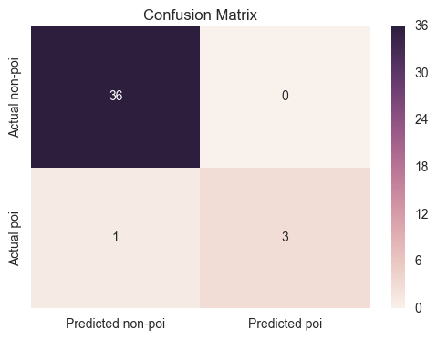

```python
confusionMatrix = confusion_matrix(labels_test, clf.predict(features_test))

ax = sns.heatmap(confusionMatrix, annot = True, fmt = ".6g", xticklabels = ['Predicted non-poi', 'Predicted poi'],
                                                             yticklabels = ['Actual non-poi', 'Actual poi'])
ax.set_title("Confusion Matrix")
```

The testing set had 40 persons and 4 persons of interest. The classifier correctly identified 3 of the 4, and never mis-identified a non-person of interest. As the size of the dataset is relatively small, we can re-run the random forest classifier multiple times against different random splits of the training/testing data. The results of running it against 1000 folds using scikit-learn's StratifiedShuffleSplit are as follows:

```python
PERF_FORMAT_STRING = "\
\tAccuracy: {:>0.{display_precision}f}\tPrecision: {:>0.{display_precision}f}\t\
Recall: {:>0.{display_precision}f}\tF1: {:>0.{display_precision}f}\tF2: {:>0.{display_precision}f}"
RESULTS_FORMAT_STRING = "\tTotal predictions: {:4d}\tTrue positives: {:4d}\tFalse positives: {:4d}\
\tFalse negatives: {:4d}\tTrue negatives: {:4d}"

test_classifier(clf, data_dict, features_list, folds = 1000)
```

```
RandomForestClassifier(bootstrap=True, class_weight=None, criterion='entropy',
            max_depth=None, max_features='auto', max_leaf_nodes=None,
            min_impurity_split=1e-07, min_samples_leaf=1,
            min_samples_split=2, min_weight_fraction_leaf=0.0,
            n_estimators=250, n_jobs=1, oob_score=False, random_state=None,
            verbose=0, warm_start=False)
	Accuracy: 0.96179	Precision: 0.94529	Recall: 0.77750	F1: 0.85322	F2: 0.80612
	Total predictions: 14000	True positives: 1555	False positives:   90	False negatives:  445	True negatives: 11910
```

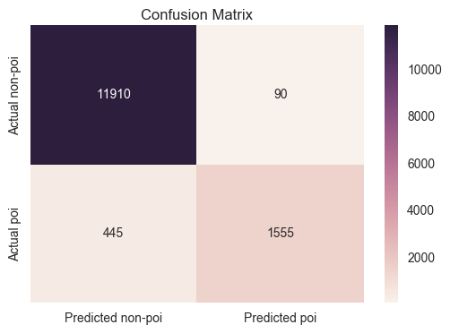

```python
ax = sns.heatmap([[11910, 90], [445, 1555]], annot = True, fmt = ".6g", xticklabels = ['Predicted non-poi', 'Predicted poi'],
                                                             yticklabels = ['Actual non-poi', 'Actual poi'])
ax.set_title("Confusion Matrix")
```

With an F1 score of 0.85322, we can see that using this combination of features was very successful in predicting whether or not someone was a person of interest, demonstrating the power of supplementing data with text learning features.